# Final Report

## 3.4 Results exploration

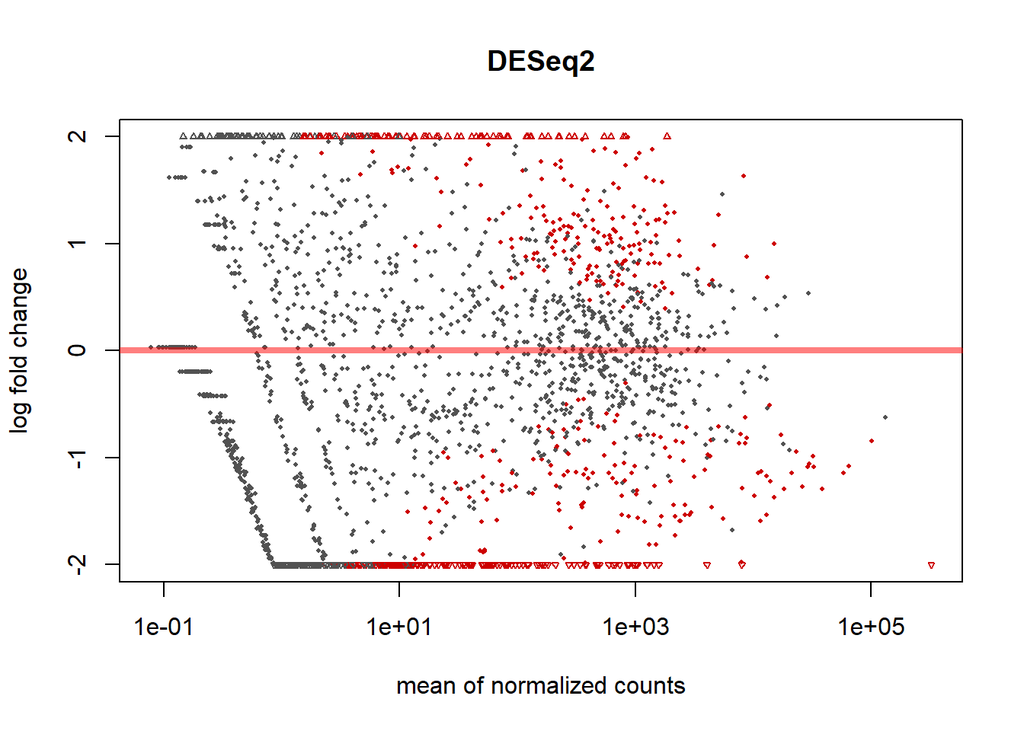

```r
# MA-plot
plotMA(res, main="DESeq2", ylim=c(-2,2))
```

As for the read counts, the MA plot can represent a global vision of the differences between the samples. In this graph, it is easy to check that there are various subexpressed and overexpressed genes.

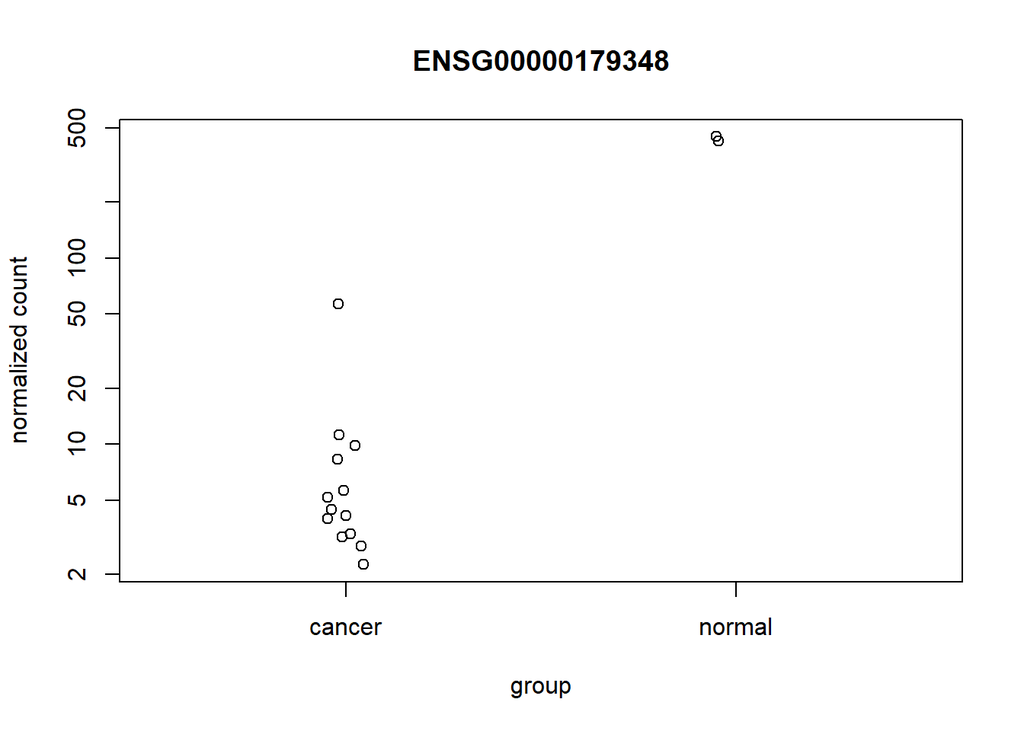

```r
# representar graficamente os read-counts para o gene mais sigfnificante
plotCounts(dds, gene=which.min(res$padj), intgroup="disease")
```

```r
# Exportaçao para um .CSV
write.csv(as.data.frame(resOrdered),file="disease_treated_results.csv")
```

## 3.5 Data transformation and visualization

Counting transformation: In order to test differential expression, discrete distributions were used for the “raw counts”.

```r
# VST: varianceStabilizingTransformation
vsd <- varianceStabilizingTransformation(dds, blind=FALSE)
head(assay(vsd), 20)
```

```
##                  csc1_sc2  csc1_dc2  csc1_sc3  csc1_dc3   csc1-dc   csc1-mc
## ENSG00000001617  5.089414  6.418309  6.010239  7.548305  6.124703  7.279380
## ENSG00000003756  9.074094  8.641985  9.316561  8.283581  8.276009  9.309099
## ENSG00000004399  6.519280  6.448674  7.153594  7.770129  6.876571  6.567041
## ENSG00000004534  9.123621  9.179776  9.260982  9.161952  9.645310 10.294836
## ENSG00000004838  3.528909  4.033408  2.843311  3.130937  2.267487  3.913095
## ENSG00000007402  4.397699  5.022019  4.207863  4.452644  4.191884  4.284043
## ENSG00000008226  5.773327  5.769322  5.992636  6.880391  5.802560  3.460905
## ENSG00000008300  8.607148  8.820437  7.968605  7.342423  8.219529  8.470740
## ENSG00000008324  8.319001  8.699766  8.211218  8.241842  7.546754  6.811054
## ENSG00000008952  9.979534 10.233408 10.165287 10.199746 10.273868 10.962058
## ENSG00000010256 10.856633 10.989122 10.588761 10.701027 11.709065 10.689453
## ENSG00000010282  2.845873  2.888758  3.076595  2.882524  2.267487  2.766221
## ENSG00000010318  5.665056  5.474836  5.045394  5.226462  6.039841  6.407806
## ENSG00000010319  4.557449  3.327864  5.462075  4.678272  4.490518  6.387855
## ENSG00000010322  9.391320  9.594507  9.197458  9.450947  9.149228  9.768244
## ENSG00000010327  4.606676  5.140313  4.331808  4.323425  4.349831  2.969378
## ENSG00000011198  7.655822  7.454801  8.088842  7.799205  7.287447  8.823365
## ENSG00000011376  8.951454  8.749252  8.936438  8.905499  9.425788  8.564536
## ENSG00000012171  8.223785 10.085934  7.936911  9.197317  8.707589  7.207381
## ENSG00000012223  2.267487  2.888758  2.843311  3.317516  2.267487  3.123036
##                   csc1-sc   csc2-dc   csc2-mc   csc2-sc   csc3-dc   csc3-mc
## ENSG00000001617  5.148471  5.892116  6.883055  5.052792  8.086739  7.381878
## ENSG00000003756  8.598165  8.345817  8.938189  8.419886  8.111392  9.192219
## ENSG00000004399  7.286079  7.083381  8.399809  7.475582  8.556516  8.230486
## ENSG00000004534  9.275668  9.969253 10.270581  9.340913 10.143014  9.903179
## ENSG00000004838  3.601060  3.256093  3.932834  3.730610  3.638331  3.941562
## ENSG00000007402  4.248459  4.278371  5.087873  4.552639  5.681914  5.629966
## ENSG00000008226  5.611596  5.445441  5.449833  5.508188  6.475762  5.567745
## ENSG00000008300  7.720163  8.023962  8.454831  7.970413  8.444567  8.951081
## ENSG00000008324  8.275210  7.676865  7.254436  7.857520  7.438338  7.381878
## ENSG00000008952 10.524429 10.299450 10.289964 10.274792 10.112816 10.478093
## ENSG00000010256 11.708567 11.424707 11.485750 11.664369 11.726449 11.241289
## ENSG00000010282  2.267487  3.079794  3.263363  3.022171  2.267487  2.930480
## ENSG00000010318  5.874979  6.020302  6.107774  6.128289  5.725506  5.325429
## ENSG00000010319  5.320393  4.452307  5.527408  4.860440  4.275181  5.207239
## ENSG00000010322  9.029722  9.077011  9.762979  9.030993  9.541152  9.821382
## ENSG00000010327  4.564524  4.505480  3.800418  4.367163  5.332086  4.719302
## ENSG00000011198  7.546939  7.356269  7.243104  7.185905  6.910469  7.635840
## ENSG00000011376  9.077672  9.401787  9.313188  9.276522  9.258098  9.169062
```

[output cut: 8 more lines]

```
## ENSG00000007402  4.882511  4.149317  4.358836
## ENSG00000008226  5.356959  4.701058  4.941430
## ENSG00000008300  8.723306  6.673092  8.234926
## ENSG00000008324  7.249584  7.295405  7.363135
## ENSG00000008952 10.861805 10.684585 10.699309
## ENSG00000010256 10.699433 10.974188 10.946968
## ENSG00000010282  2.267487  2.267487  2.267487
## ENSG00000010318  5.178502  6.203500  6.070209
## ENSG00000010319  5.736561  5.855666  5.972627
## ENSG00000010322  8.917893 10.079602 10.107591
## ENSG00000010327  4.439939  2.267487  4.358836
## ENSG00000011198  7.539151  8.770446  8.934360
## ENSG00000011376  8.975537 10.135049 10.128864
## ENSG00000012171  7.828637  8.738975  9.883953
## ENSG00000012223  2.267487  3.080571  2.267487
```

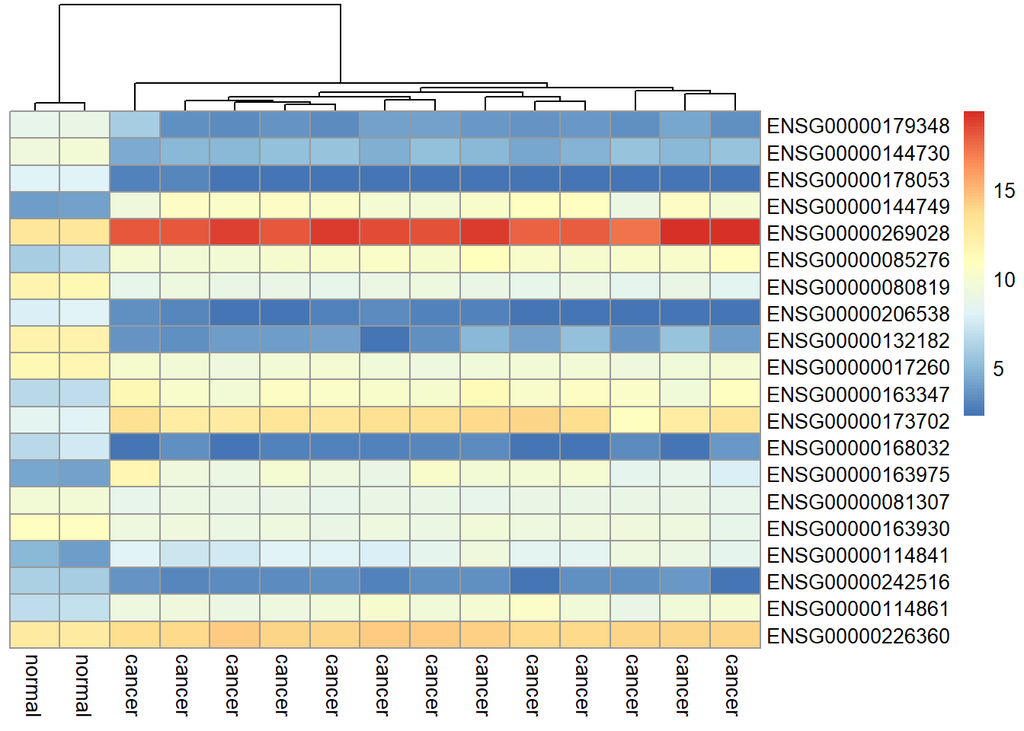

```r
# comparar o comando previo com head(counts(dds), 3)
# Heatmap da matriz dos counts
select <- rownames(head(resOrdered,20))
vsd.counts <- assay(vsd)[select,]
colnames(vsd.counts)<-metadata$disease
df <- as.data.frame(colData(dds)[,c("disease")])
# manter a ordenação das linhas
library(pheatmap)
pheatmap(vsd.counts, cluster_rows=FALSE,show_colnames = T)
```

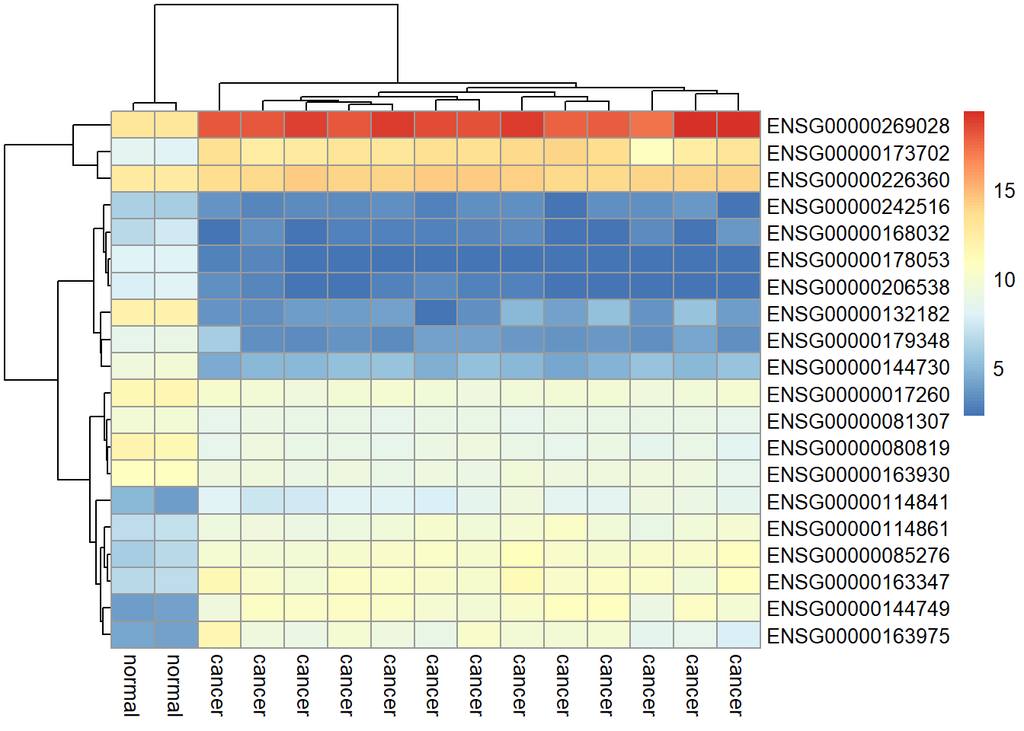

```r
# cluster por linha e coluna
pheatmap(vsd.counts)
```

The results from the differential expression analysis revealed that the gene with the ENSG00000269028 ENSEMBLE ID was overexpressed for the cancer cells. The gene is MTRNR2L12 and the codified protein is dubbed as Humanin-like 12). This protein is codified by a small Open Reading Frame (ORF) in the mitochondrial DNA (mtDNA) [3]. Its function is to supress apoptosis [2]. Once that an apoptosis disruption is directly linked with cancer [4], this is the expected result.

## 3.6 Heatmaps about the Eucledian distance between samples

```r
# calcular a distancia entre amostras
sampleDists <- dist(t(assay(vsd)))

# preparar a matriz de distancias
sampleDistMatrix <- as.matrix(sampleDists)
rownames(sampleDistMatrix) <- dds$sample
colnames(sampleDistMatrix) <- NULL
```

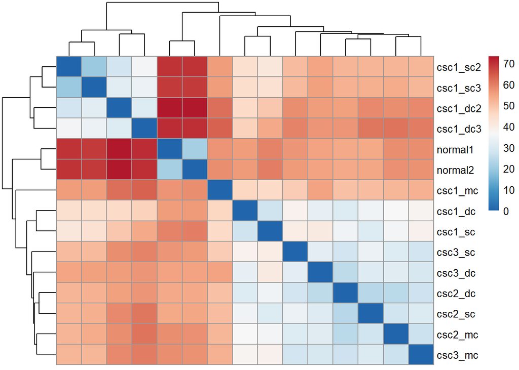

```r
library(RColorBrewer)
colors <- colorRampPalette( rev(brewer.pal(9, "RdBu")) )(255)
pheatmap(sampleDistMatrix, clustering_distance_rows=sampleDists,
         clustering_distance_cols=sampleDists, col=colors)
```

In the above heatmap, it is possible to verify that the normal samples data tends to group, as well as the other samples. However, the 2 and 3 replicates, collected from the first patient, group themselves, as well as the rest generate another cluster.

## 3.7 Principal Component Analysis

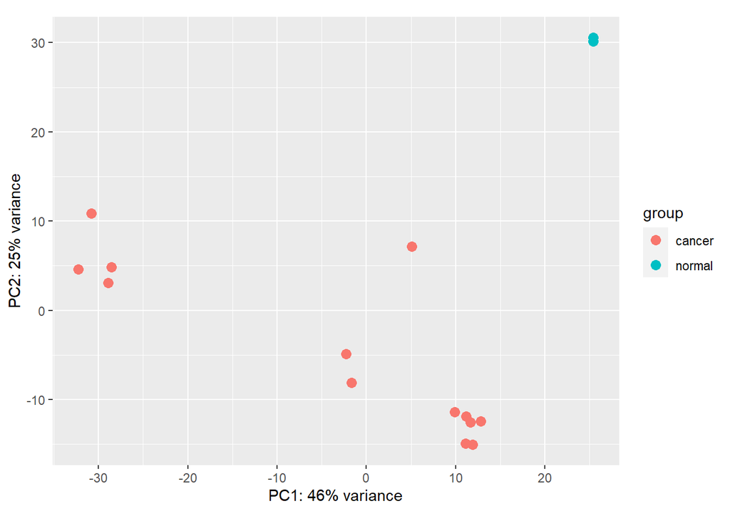

```r
plotPCA(vsd, intgroup=c("disease"))
```

The Principal Component Analysis (PCA) revealed a natural separation between the healthy people samples and the other from the Gastric Cancer patients.

In order to annotate the relevant genes, the following command was used:

```r
anno <- AnnotationDbi::select(hgu95av2.db,
                              keys=rownames(resOrdered),
                              columns=c("SYMBOL","SYMBOL", "GENENAME"),
                              keytype="ENSEMBL")
```

# 4 Discussion

The results from the RNA-Seq data analysis did not allow to take relevant conclusions, even though the results correponded with the expected. In order to come across with better conclusions, a genome-wide analysis) must be performed. Furthermore, an analysis such as the mentioned would give us importatant insights into the understanding of how epigenomic alterations in proximal and distal regions of the human genome could have an importatn role in the development of GC.

[1]Baek, S., Kim, M., Bae, D., Kim, J., Kim, H., Han, M., Oh, S., Kim, Y. and Kim, S. (2015). Integrated epigenomic analyses of enhancer as well as promoter regions in gastric cancer. Oncotarget

[2]Guo B, Zhai D, Cabezas E, Welsh K, Nouraini S, Satterthwait AC, Reed JC (May 2003). “Humanin peptide suppresses apoptosis by interfering with Bax activation”. Nature. 423 (6938)

[3]Bodzioch M, Lapicka-Bodzioch K, Zapala B, Kamysz W, Kiec-Wilk B, Dembinska-Kiec A (October 2009). “Evidence for potential functionality of nuclearly-encoded humanin isoforms”. Genomics. 94 (4): 247-56. doi:10.1016/j.ygeno.2009.05.006. PMID 19477263.

[4]Scott W. Lowe, Athena W. Lin, Apoptosis in cancer , Carcinogenesis, Volume 21, Issue 3, March 2000, Pages 485-495